# hw4_cjf

Chris Fenton

July 4, 2016

Libraries:

```r
library(stringr)
library(PerformanceAnalytics)
```

```r
library(aod)
library(ggplot2)
library(Rcpp)
library(Amelia)
```

Loading the data:

```r
ins <- read.csv('insurance_training_data.csv',na.strings=c("","NA"),stringsAsFactors = FALSE)
```

# Data Exploration

```r
#check for missing values
sapply(ins, function(x) sum(is.na(x)))
```

```
##       INDEX TARGET_FLAG  TARGET_AMT    KIDSDRIV         AGE    HOMEKIDS
##           0           0           0           0           6           0
##         YOJ      INCOME     PARENT1    HOME_VAL     MSTATUS         SEX
##         454         445           0         464           0           0
##   EDUCATION         JOB    TRAVTIME     CAR_USE    BLUEBOOK         TIF
##           0         526           0           0           0           0
##    CAR_TYPE     RED_CAR    OLDCLAIM    CLM_FREQ     REVOKED     MVR_PTS
##           0           0           0           0           0           0
##     CAR_AGE  URBANICITY
##         510           0
```

There are 2116 incomplete observations (missing at least one variable value), these will need to either be imputed or dropped.

```r
#chart.Correlation(ins[,-c(9,11,12,13,14,16,19,20,23,26)])
```

# Data Transformation

Converting the money character fields to numeric.

```r
blue_book <- unname(sapply(ins$BLUEBOOK, str_replace_all, '[,$]', ''))
blue_book <- as.numeric(blue_book)

income <- unname(sapply(ins$INCOME, str_replace_all, '[,$]', ''))
income <- as.numeric(income)

home_val <- unname(sapply(ins$HOME_VAL, str_replace_all, '[,$]', ''))
home_val <- as.numeric(home_val)

old_claim <- unname(sapply(ins$OLDCLAIM, str_replace_all, '[,$]', ''))
old_claim <- as.numeric(old_claim)

ins$BLUEBOOK <- blue_book
ins$INCOME <- income
ins$HOME_VAL <- home_val
ins$OLDCLAIM <- old_claim
```

Converting the categoricals to factors:

```r
ins$CAR_TYPE <- factor(ins$CAR_TYPE)
ins$CAR_USE <- factor(ins$CAR_USE)
ins$EDUCATION <- factor(ins$EDUCATION)
ins$JOB <- factor(ins$JOB)
ins$MSTATUS <- factor(ins$MSTATUS)
ins$PARENT1 <- factor(ins$PARENT1)
ins$RED_CAR <- factor(ins$RED_CAR)
ins$REVOKED <- factor(ins$REVOKED)
ins$SEX <- factor(ins$SEX)
ins$URBANICITY <- factor(ins$URBANICITY)
```

Create numeric data frame:

```r
ins_num <- ins[,-c(1,9,11,12,13,14,16,19,20,23,26)]
```

# Multiple Linear Regression Model to Predict TARGET_AMT

Only look at observations that paid out.

```r
ins_payout <- subset(ins, TARGET_AMT != 0)
```

Adding log of Target Amount

```r
ins_payout$TARGET_AMT_LOG <- log(ins_payout$TARGET_AMT)
ins_payout$BLUEBOOK_LOG <- log(ins_payout$BLUEBOOK)
ins_payout$INCOME_LOG <- log(ins_payout$INCOME)

ins_payout$INCOME_LOG <- log(ins_payout$INCOME)
```

Check to confirm that they were all in crashes.

```r
ins_payout2 <- ins[ins$TARGET_AMT != 0 & ins$TARGET_FLAG == 1,]
```

Look to see what variables have linear relationship with TARGET_AMT, thus eligible to be used/transformed into a regression model.

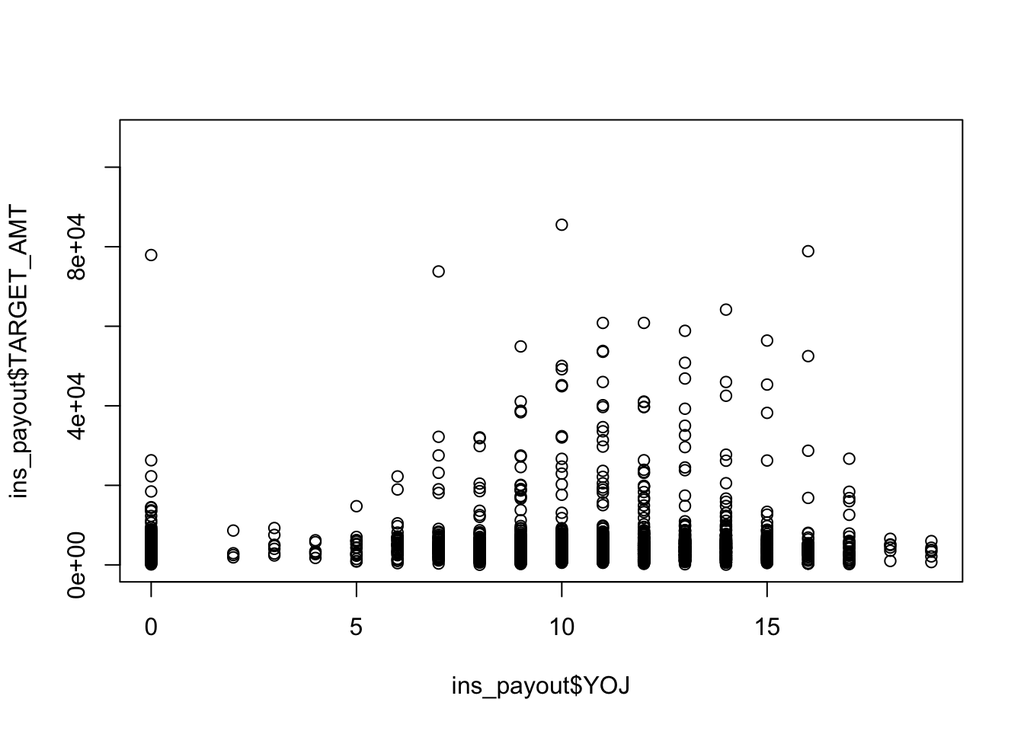

```r
plot(ins_payout$YOJ, ins_payout$TARGET_AMT)
```

```r
blue_book_model_log <- lm(TARGET_AMT_LOG ~ BLUEBOOK_LOG, data=ins_payout)
blue_book_model_2 <- lm(TARGET_AMT_LOG ~ BLUEBOOK_LOG + CAR_AGE + CAR_TYPE, data=ins_payout)

summary(blue_book_model_log)
```

```
##
## Call:
## lm(formula = TARGET_AMT_LOG ~ BLUEBOOK_LOG, data = ins_payout)
##
## Residuals:
##     Min      1Q  Median      3Q     Max
## -4.7888 -0.3907  0.0425  0.3914  3.2417
##
## Coefficients:
##              Estimate Std. Error t value Pr(>|t|)
## (Intercept)   6.77803    0.24679  27.465  < 2e-16 ***
## BLUEBOOK_LOG  0.15976    0.02626   6.085 1.38e-09 ***
## ---
## Signif. codes:  0 '***' 0.001 '**' 0.01 '*' 0.05 '.' 0.1 ' ' 1
##
## Residual standard error: 0.8058 on 2151 degrees of freedom
## Multiple R-squared:  0.01692,    Adjusted R-squared:  0.01646
## F-statistic: 37.02 on 1 and 2151 DF,  p-value: 1.377e-09
```

```r
summary(blue_book_model_2)
```

```
##
## Call:
## lm(formula = TARGET_AMT_LOG ~ BLUEBOOK_LOG + CAR_AGE + CAR_TYPE,
##     data = ins_payout)
##
## Residuals:
##     Min      1Q  Median      3Q     Max
## -4.7965 -0.3949  0.0322  0.3864  3.2269
##
## Coefficients:
##                       Estimate Std. Error t value Pr(>|t|)
## (Intercept)          6.8785593  0.2999254  22.934  < 2e-16 ***
## BLUEBOOK_LOG         0.1468874  0.0318664   4.609 4.29e-06 ***
## CAR_AGE             -0.0008467  0.0032776  -0.258    0.796
## CAR_TYPEPanel Truck  0.0934511  0.0805493   1.160    0.246
## CAR_TYPEPickup       0.0284889  0.0593776   0.480    0.631
## CAR_TYPESports Car   0.0254116  0.0655049   0.388    0.698
## CAR_TYPEVan          0.0429734  0.0753737   0.570    0.569
## CAR_TYPEz_SUV        0.0248701  0.0546819   0.455    0.649
## ---
## Signif. codes:  0 '***' 0.001 '**' 0.01 '*' 0.05 '.' 0.1 ' ' 1
##
## Residual standard error: 0.8001 on 2003 degrees of freedom
##   (142 observations deleted due to missingness)
## Multiple R-squared:  0.0177, Adjusted R-squared:  0.01427
## F-statistic: 5.157 on 7 and 2003 DF,  p-value: 7.827e-06
```

The variables `CAR_AGE` and `CAR_TYPE` were indidcated as “probably effect[ing] the payout if there is a crash” in the dataset description. However, they are not found to be signficantly impacting the `TARGET_AMT` variable. Furthermore, the adjusted R-Squared is marginally higher without these variables. Thus `blue_book_model_log` is the better model to proceed with.

Verifying the assumptions of `blue_book_model_log`:

Linearity:

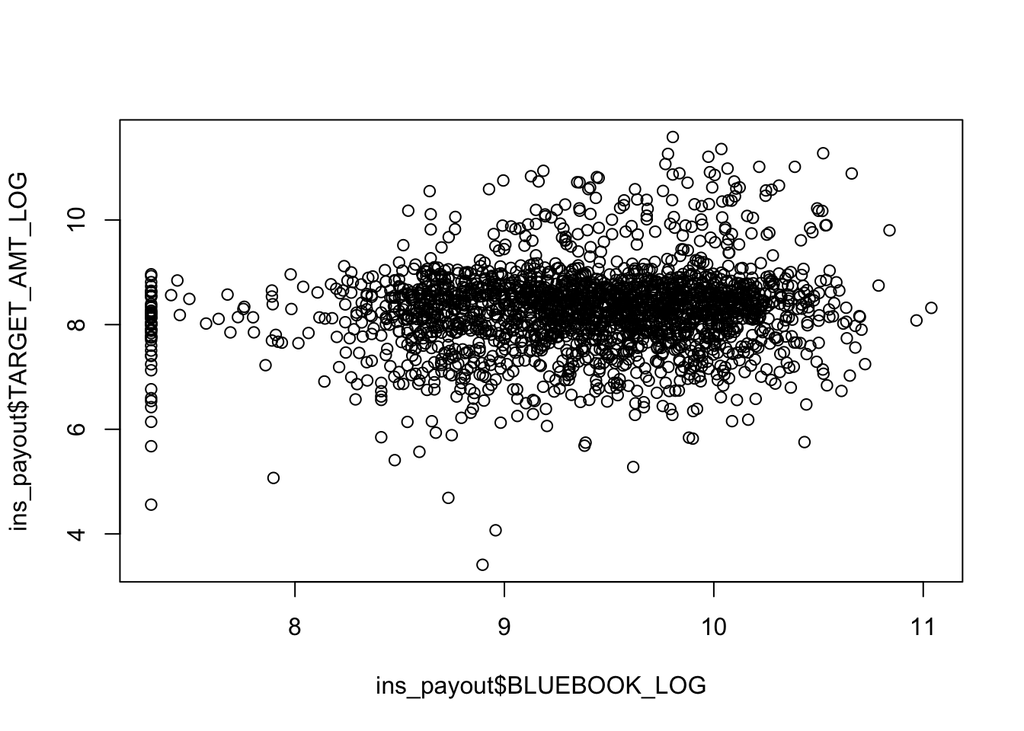

```r
plot(ins_payout$BLUEBOOK_LOG, ins_payout$TARGET_AMT_LOG)
```

```r
cor(ins_payout$BLUEBOOK_LOG, ins_payout$INCOME_LOG)
```

```
## [1] NA
```

Normality, homoscedasticity, and independence of residuals:

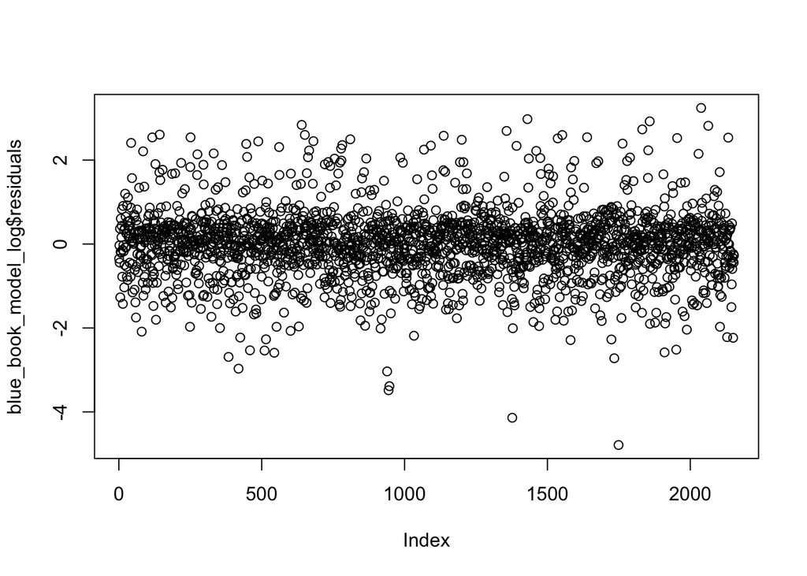

```r
plot(blue_book_model_log$residuals)
```